# A Human History Altering Event is Coming

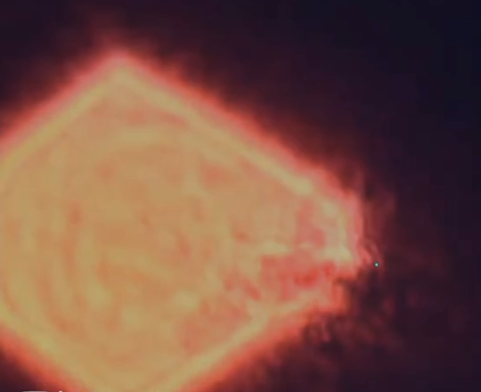

Original image screenshot

“This was the appearance and structure of the wheels: They sparkled like topaz, and all four looked alike. Each appeared to be made like a wheel intersecting a wheel.” Ezekiel 1:16

If anyone who has ever wondered how the abhorrent destruction of human life could be occurring in the land that the historical Jesus walked, and with absolute impunity so far, and for anyone else who wonders about the so-called drones and orbs, this is and easy connection for you. The lead image is one of the orbs that have been appearing worldwide often with the presence of ‘drones’ nearby. I’m focusing on the orbs. The first one is an unfiltered screen grab. The bottom has been filtered by me.

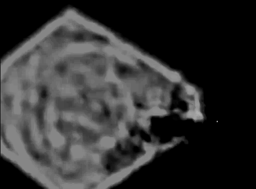

Filtered and enhanced

*You could let your mind loose on these: A diatom-shaped something with arcs within? A face in the middle? An anguished face on the right side of the unfiltered image? A giant virus breaking open in the sky? Run with your gut and you’re probably close.

**Is this what Ezekiel saw?** Here are snippets of what he said: Ezekiel 1:4-6

> I looked, and I saw a windstorm coming out of the north — an immense cloud with flashing lightning and surrounded by brilliant light. The center of the fire looked like glowing metal, and in the fire was what looked like four living creatures. In appearance their form was human, but each of them had four faces and four wings.

If any of these images are not AI or CGI created, then this is a new dimensional upgrade into what is actually happening on this planet. I’ve stated many times that I am not a Christian or an anything else but that I am a student and follower of love in the universe if I’m anything. One reason I am not Christian is that Jesus never once said to create a religion in my name, worship me, use my name, image, impartations of the truth from me for anything, other than we should love one another. That was the message - **To Love One Another**. Unconditionally so, yet, here we are thousands of years later and humans have made a hellish history on this earth, the result of the transmogrification of the being and the being’s message of unconditional love.

In the Bible, which in my view is the result of strategically manipulative men, no women allowed, there exists much imagery and visions possibly overlooked by the political forces of the Council of Nicaea. I say overlooked because politics, exclusive groups of men, and the power they wield would fall well under the auspices of divine warnings and retribution. Maybe they didn’t understand it. Or misinterpreted its importance. Or feared the wrath themselves if omitted and so let it remain. Fortunately, for us, through to the more modern revisitations, it has survived. The following is from **Ezekiel** and the infamous wheel in the Bible. I’ve taken choice pieces of Ezekiel 7 here. These are some of the more mild passages if you can believe it. The full texts are a bit long and strong. For the unaware or unread of this biblical text, most of it is pretty dark, ominous, vengeful, and violent stuff. A lot of he Old Testament is this way. It warns of who holds the utmost, supreme power. I don’t think this power was or is very happy with quite a few things going on down there in the old Holy Land, then or now. I’d wager heavily on the latter. It’s just too prescient and poignant to ignore. From [Ezekiel 7 5:9 New International Version](https://www.biblegateway.com/passage/?search=Ezekiel%207&version=NIV).

> 5 “’Disaster! Unheard-of disaster! See, it comes!  
> 6 The end has come! The end has come! It has roused itself against you. See, it comes!  
> 7 Doom has come upon you, upon you who dwell in the land. The time has come! The day is near! There is panic, not joy, on the mountains.  
> 8 I am about to pour out my wrath on you and spend my anger against you. I will judge you according to your conduct and repay you for all your detestable practices.  
> 9 I will not look on you with pity; I will not spare you. I will repay you for your conduct and for the detestable practices among you.

> “’Then you will know that it is I the Lord who strikes you.

It doesn’t bode well for evil-doing and contains quite a show and demonstration of who or what truly has the power. **I AM** seems to mean business. It sounds like a mean business of retribution. Bibi, et alia, are you listening???

The fed, and the media of late has tried to let all the air space incursions die or to bury this evolving story, but they can’t. It is far beyond their pay grade to even attempt. You now need to check on your own time and winnow through the AI/CGI bullshit to the real stuff. The hearings keep happening. The chatter and curiosity only grows within the public. They know it. This is no Project Bluebeam deception nonsense. They hope it all goes away but I don’t think that’s going to happen. It’s like they thought that no one was watching their destruction of life and joy for all these years as if the perpetrators had a free pass, but they were being watched. I’m feeling a great purging about to happen and we will have known nothing like it in human history. An emergency intervention so to speak where the last do become the first but hopefully embedded with a truth and caring discipline that disallows the former human disease that gives us genocide and masses of people in dire need with nothing but misery and death to await.

> Today and everyday ask yourself, “Is what I’m going to do today serving the love of the planet or the love of humanity?” If not, Don’t Do It!

*To the people who have read my works - so much gratitude and many thanks! Please share with someone. Please support this type of work if you can.*

[interactive chart not shown]